# EDA SIP

Julie Pessoa

## O que são os dados

```
## Observations: 12,299
## Variables: 17
## $ TaskNumber           <chr> "1735", "1742", "1971", "2134", "2251", "...
## $ Summary              <chr> "Flag RI on SCM Message Summary screen us...
## $ Priority             <dbl> 1, 1, 2, 5, 10, 1, 5, 5, 6, 5, 2, 1, 3, 1...
## $ RaisedByID           <chr> "58", "58", "7", "50", "46", "13", "13", ...
## $ AssignedToID         <chr> "58", "42", "58", "42", "13", "13", "13",...
## $ AuthorisedByID       <chr> "6", "6", "6", "6", "6", "58", "6", "6", ...
## $ StatusCode           <chr> "FINISHED", "FINISHED", "FINISHED", "FINI...
## $ ProjectCode          <chr> "PC2", "PC2", "PC2", "PC2", "PC2", "PC9",...
## $ ProjectBreakdownCode <chr> "PBC42", "PBC21", "PBC75", "PBC42", "PBC2...
## $ Category             <chr> "Development", "Development", "Operationa...
## $ SubCategory          <chr> "Enhancement", "Enhancement", "In House S...
## $ HoursEstimate        <dbl> 14.00, 7.00, 0.70, 0.70, 3.50, 7.00, 7.00...
## $ HoursActual          <dbl> 1.75, 7.00, 0.70, 0.70, 3.50, 7.00, 7.00,...
## $ DeveloperID          <chr> "58", "42", "58", "42", "13", "13", "43",...
## $ DeveloperHoursActual <dbl> 1.75, 7.00, 0.70, 0.70, 3.50, 7.00, 7.00,...
## $ TaskPerformance      <dbl> 12.25, 0.00, 0.00, 0.00, 0.00, 0.00, 0.00...
## $ DeveloperPerformance <dbl> 12.25, 0.00, 0.00, 0.00, 0.00, 0.00, NA, ...
```

## Entendendo os dados

```
## Skim summary statistics
##  n obs: 12299
##  n variables: 4
##
## -- Variable type:character ---------------------------------------------------------------------------------------------------------
##     variable missing complete     n min max empty n_unique
##  ProjectCode       0    12299 12299   3   4     0       20
##   TaskNumber       0    12299 12299   4   5     0    10266
##
## -- Variable type:numeric -----------------------------------------------------------------------------------------------------------
##       variable missing complete     n  mean    sd   p0 p25 p50 p75    p100
##    HoursActual       0    12299 12299 13.18 68.72 0.01   1   3 8.5 2490.16
##  HoursEstimate       0    12299 12299 10.15 28.84 0.01   1   3 7    910
##      hist
##  ▇▁▁▁▁▁▁▁
##  ▇▁▁▁▁▁▁▁
```

Temos 20 projetos, com 12299 estimativas_raw. Não há apenas uma estimativa por tarefa, já que há apenas 10266 valores distintos de `TaskNumber`.

```
## # A tibble: 1,384 x 2
## # Groups:   TaskNumber [1,384]
##    TaskNumber     n
##    <chr>      <int>
##  1 10605          8
##  2 6889           8
##  3 10089          7
##  4 10974          7
##  5 11056          7
##  6 11270          7
##  7 13124          7
##  8 13190          7
##  9 13253          7
## 10 3812           7
## # ... with 1,374 more rows
```

### 1 estimativa por task

Para nossa análise, usaremos uma estimativa por task. Caso haja mais de uma usaremos a média das estimativas_raw:

```
## # A tibble: 10,268 x 8
##    ProjectCode TaskNumber Category Priority Summary HoursEstimate
##    <chr>       <chr>      <chr>       <dbl> <chr>           <dbl>
##  1 PC1         11276      Managem~        3 Meetin~            14
##  2 PC1         11286      Develop~        1 CCC Fi~            35
##  3 PC1         11294      Develop~        1 Develo~            21
##  4 PC1         11306      Develop~        1 CCC me~            14
##  5 PC1         11313      Develop~        1 CCC Zo~            28
##  6 PC1         11316      Develop~        1 Zone C~            14
##  7 PC1         11325      Develop~        1 CCC De~            49
##  8 PC1         11327      Develop~        1 CCC Ge~           100
##  9 PC1         11331      Managem~        1 CCC Me~             1
## 10 PC1         11335      Develop~        1 Create~            21
## # ... with 10,258 more rows, and 2 more variables: HoursActual <dbl>,
## #   DeveloperPerformance <dbl>
```

### Dados por time

```
## # A tibble: 20 x 4
##    ProjectCode  devs erro_medio_abs estimativas
##    <chr>       <int>          <dbl>       <int>
##  1 PC1             4          18.5           54
##  2 PC10            4          35.9           73
##  3 PC11           11           4.60         292
##  4 PC12            3           8.27          54
##  5 PC13            6           8.50         171
##  6 PC14           11          90.4          105
##  7 PC15            3           1.87           3
##  8 PC16            8           9.59         114
##  9 PC17           10          15.0          449
## 10 PC18           15          14.2         2888
## 11 PC19            1           3.90          41
## 12 PC2            16           4.15        4553
## 13 PC20            2          98.7            5
## 14 PC3             5           5.03          87
## 15 PC4             8           4.95         511
## 16 PC5             8          12.2          648
## 17 PC6             6          10.7          287
## 18 PC7            10          10.8          145
## 19 PC8            11           6.07          64
## 20 PC9            14          11.9         1755
```

## Qual a relação entre as estimativas e horas reais tomadas na empresa como um todo e em diferentes categorias de tarefa?

#### Análise da empresa como um todo

Inicialmente, dando uma olhada geral nos dados temos:

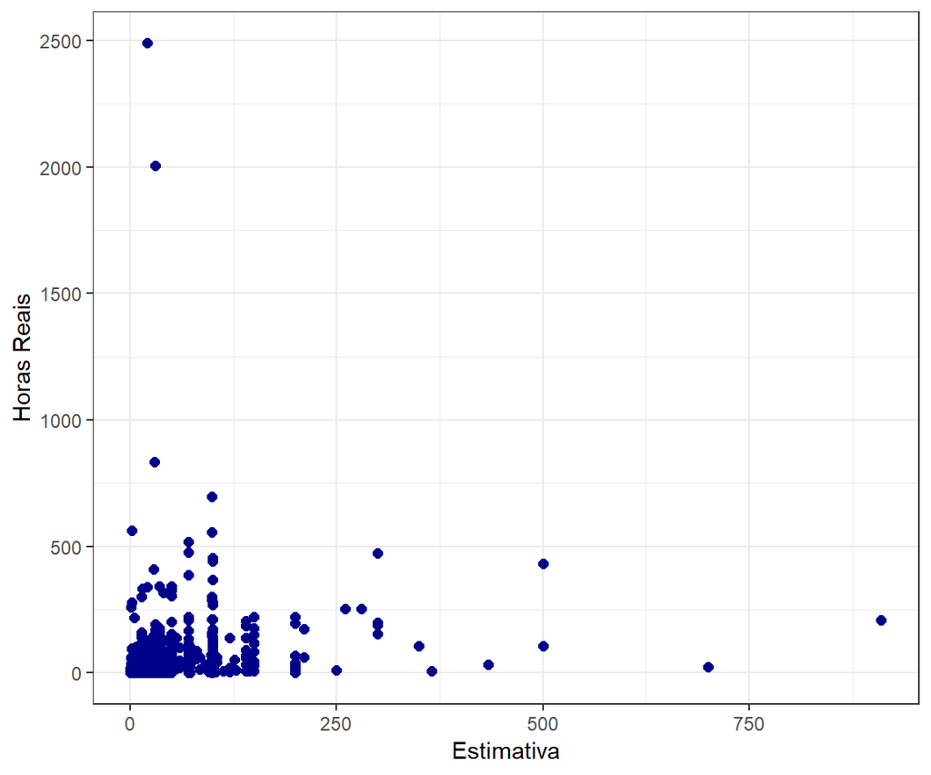

Podemos perceber que há uma concentração próximo ao zero. É possível notar que a relação entre estimativas e horas reais não é linear, podendo ser comprovado pela correlação de Pearson.

Correlações entre Estimativa e Horas Reais

| pearson | spearman | kendall |
| --- | --- | --- |
| 0.3159804 | 0.8260454 | 0.6958933 |

A correlação de Person tem facilidade em captar correlações lineares e dado esse valor de 0.3 podemos concluir que a correlação é bem fraca. Não sendo linear, e observando que os métodos de spearman e kendall obtiveram resultados que propoe que há uma correlação entre as duas variáveis, podemos verficar os dados a partir de outra escala, como por exemplo a logaritmica.

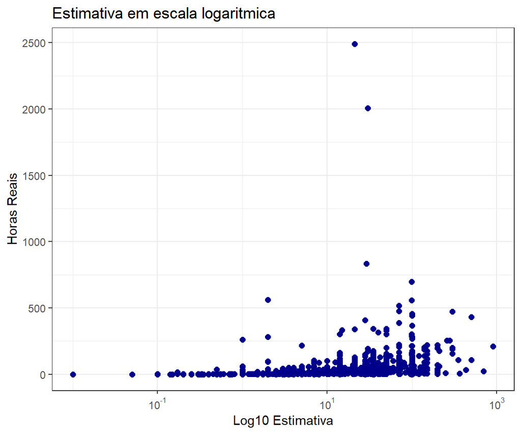

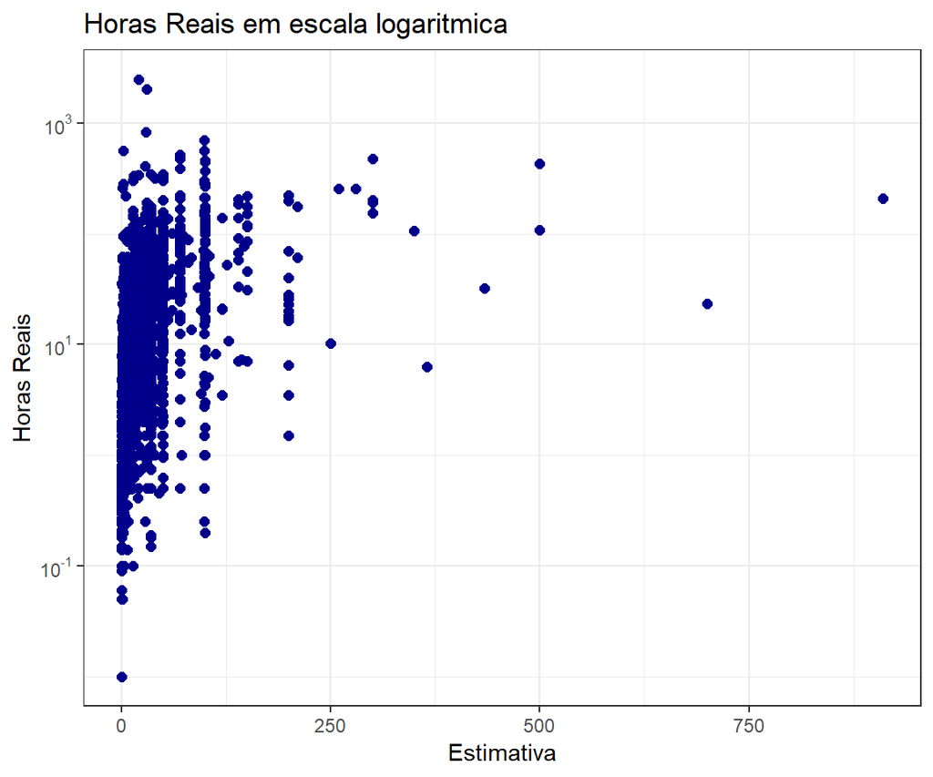

Aparentemente, utilizando a escala logaritmica em apenas uma grandeza ainda não é possível verificar uma correlação linear forte. Há uma melhora na correlação ao utilizar a variavel HoursActual em base logaritmica como é demonstrado abaixo pela correlação de pearson.

Correlações entre o log10 da estimativa e as Horas reais

| pearson |
| --- |
| 0.2908308 |

Correlações da Estimativa e o log10 das horas reais

| pearson |
| --- |
| 0.4389547 |

Ainda na tentativa de visualizar uma relação linear entre as duas variaveis, vamos utilizar a escala logaritmica nas duas variaveis.

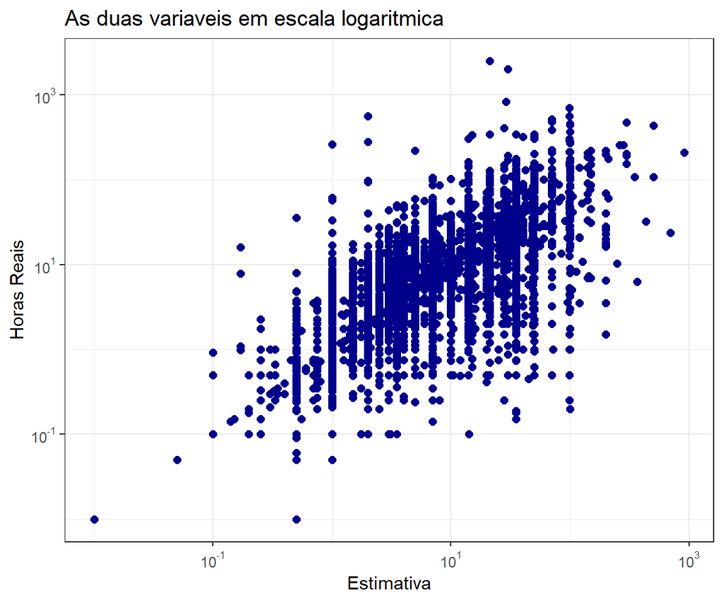

Com as duas variáveis em escala logaritmica é possível observar um correlação linear, relativamente forte e positiva entre o log da estimativa e das horas reais. Há uma tendência de que quanto maior as horas estimadas, maior as horas reais.

#### Análise das diferentes categorias de tarefas

Basicamente as correlações se mantém razoavelmente semelhante em relação as correlações gerais.

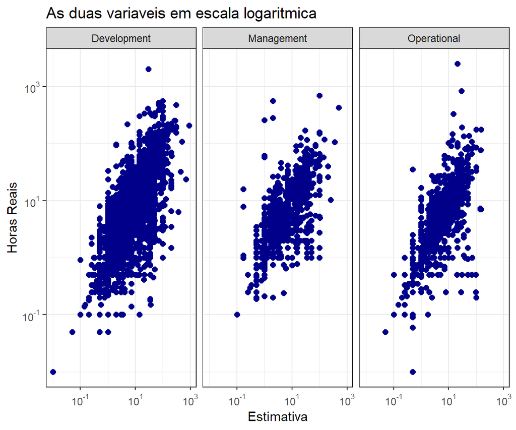

Correlações da Categoria Development

| pearson | spearman | kendall |
| --- | --- | --- |
| 0.377225 | 0.8345521 | 0.7002424 |

Correlações da Categoria Management

| pearson | spearman | kendall |
| --- | --- | --- |
| 0.4555045 | 0.7528142 | 0.6348328 |

Correlações da Categoria Operational

| pearson | spearman | kendall |
| --- | --- | --- |
| 0.1587236 | 0.8416869 | 0.7292038 |

## Equipes com mais desenvolvedores produzem estimativas com mais ou menos erro que equipes menores?

Na representação dos pontos abaixo é possível notar que não há uma correlação entre o número de desenvolvedores e o erro produzido. Observado os métodos de correlações, todos eles apresentam uma baixíssima correlação, portanto não vale a pena procurar alguma tranformação que mostre alguma correlação entre os dados.

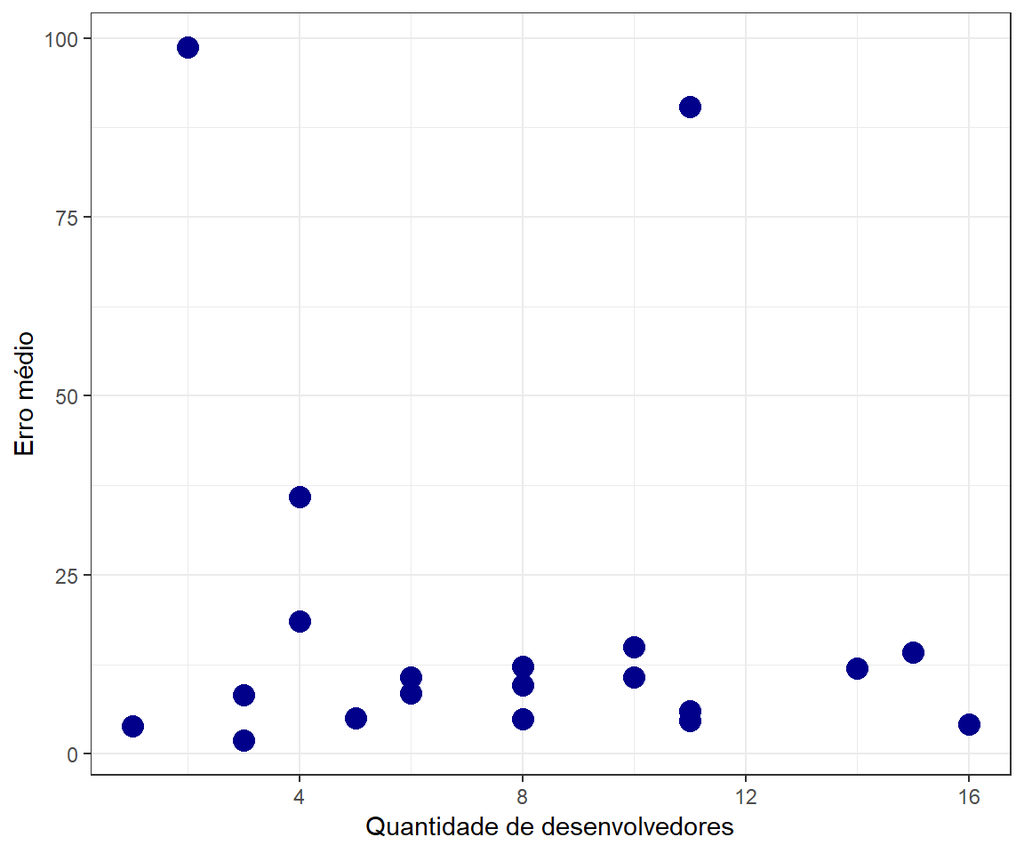

Correlações entre a quantidade de desenvolvedores e o erro produzido

| pearson | spearman | kendall |
| --- | --- | --- |
| -0.1365125 | 0.0438071 | 0.0324443 |